# Sarek Paper

AWS costs

Friederike Hanssen

August 15, 2022

[figure not shown]

QBiC

# 1 Introduction

This script plots the costs when running sarek on AWS using Tower Forge. The following experiments are conducted:

Apparently we are 2 hours in front of whatever is happning with tower. So eith erI need to start the runs at 2 in the morning or very very early after getting up. Either way, need to repeat the experiments.

| Name | Description | Tower ID | Parameters | Resource config | estimated costs |
| --- | --- | --- | --- | --- | --- |
| Germline Single sample | Sarek 3.0 run, with optimised resource requests for CHC982, germline only | https://tower.nf/user/friederike-hanssen/watch/4GLbIcExOdptqD | --tools strelka --aligner bwa-mem2 --input --outdir --igenomes_base --trace_dir |  | 30$ |
| Germline Single sample, no QC | sarek 3.0 |  |  |  | >30$ |
| Somatic, One sample | sarek 3.0 |  |  |  | 60$ |
| Somatic, one sample, no QC | sarek 3.0 |  |  |  | >60$ |
| Germline Single sample | sarek 2.7.2 |  |  |  |  |
| Germline Single sample, no QC | sarek 2.7.2 |  |  |  |  |
| Somatic, One sample | sarek 2.7.2 |  |  |  |  |
| Somatic, one sample, no QC | sarek 2.7.2 |  |  |  |  |
| Germline only, interval optimised? | sarek 3.0 |  |  |  |  |
| Run for all 5 samples together? |  |  |  |  |  |

# 2 Loading the dataset

Costs are estimated with respect to different aspects: instance type, service, and usage type. The files are downloaded from the AWS cost explorer by only searching for the date in the file name + respective selector. The downloaded files unfortunately don’t include a final empty line to indicate end-of-file. Therefore, all files need to be opened and an additional needs to be added manually. For the final plots only the usage type is needed. However, plotting the other two allows for quick sanity checks.

# 3 Overview of costs per aggregation type

Costs by instance for a single germline sample (CHC892), run with sarek 3.0:

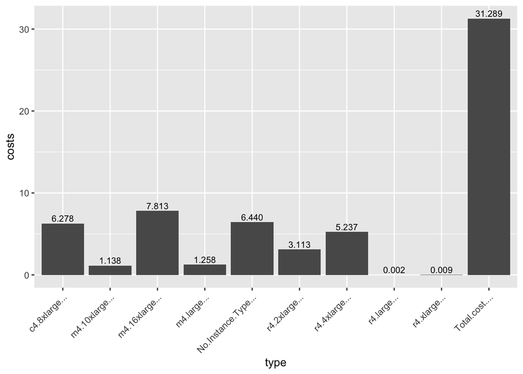

Costs by service:

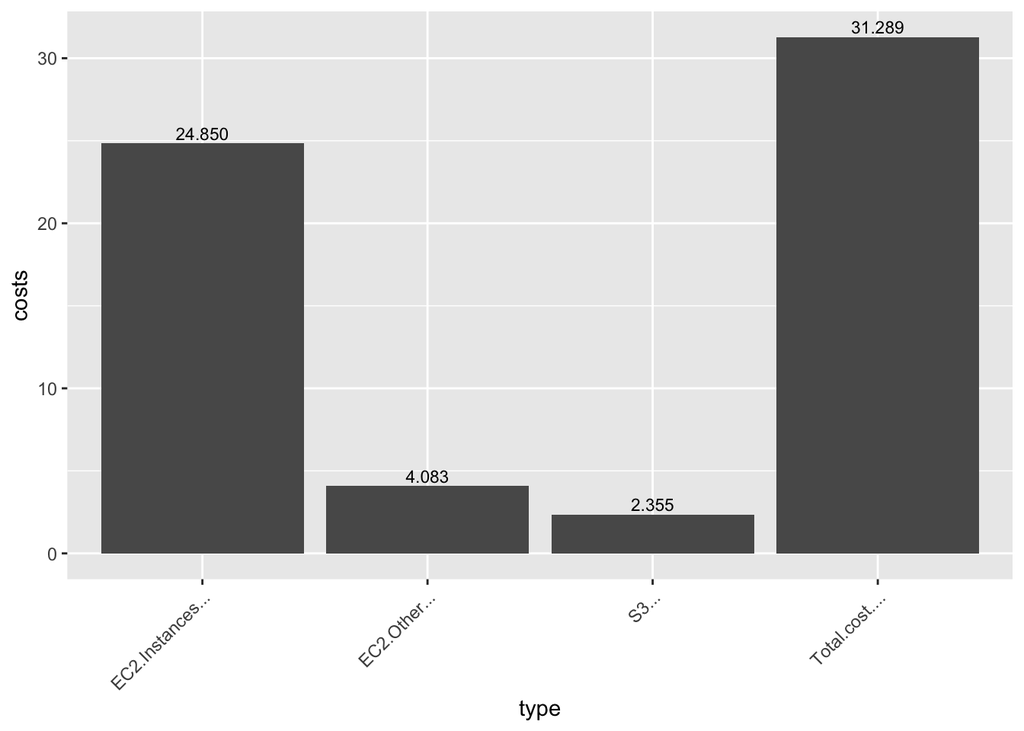

Costs by usage:

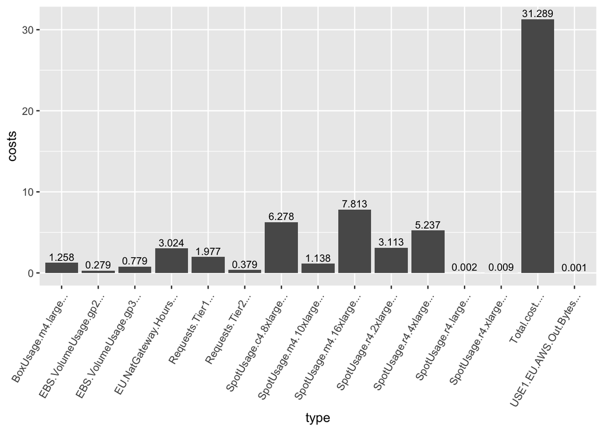

# 4 Overall cost usage

Aggregate and group costs:

```r
## Assign groups to each row type, default to "other"
germline_singlesample_30_usage <- germline_singlesample_30_usage %>%
    mutate(category = case_when(
    startsWith(type, "SpotUsage") ~ "EC2 Instances",
    startsWith(type, "BoxUsage") ~ "EC2 Instances",
    startsWith(type, "Total") ~ "Total",
    startsWith(type, "Timed") ~ "S3",
    startsWith(type, "Requests") ~ "S3",
    TRUE ~ "EC2 Other"
    ))
```

```r
germline_singlesample_30_usage_aggr <- germline_singlesample_30_usage %>%
  # To calculate total costs per category, groupby it, then sum over it
  group_by(category) %>%
  summarise(costs = sum(costs)) %>%
  # add everything after original dataset (rows)
  bind_rows(germline_singlesample_30_usage, .) %>%
  # The new rows don't have a type, copy values from category column to type
  mutate(type = coalesce(type,category)) %>%
  # Change the category of the new values to "total"
  mutate(category = replace(category, type == "EC2 Instances","Total")) %>%
  mutate(category = replace(category, type == "EC2 Other","Total")) %>%
  mutate(category = replace(category, type == "S3","Total")) %>%
  mutate(category = replace(category, type == "EC2 Other","Total")) %>%
  # Remove the now duplicated total cost row (keep all where type != Total)
  filter(type!='Total')
```

```r
germline_singlesample_30_usage_aggr <- germline_singlesample_30_usage_aggr %>%
    mutate(color = case_when(
    startsWith(category, "EC2 Instances") ~ "EC2 Instances",
    startsWith(category, "EC2 Other") ~ "EC2 Other",
    startsWith(category, "S3") ~ "S3",
    startsWith(type, "EC2 Instances") ~ "EC2 Instances",
    startsWith(type, "EC2 Other") ~ "EC2 Other",
    startsWith(type, "S3") ~ "S3",
    startsWith(type, "Total") ~ "Total",
    ))
```

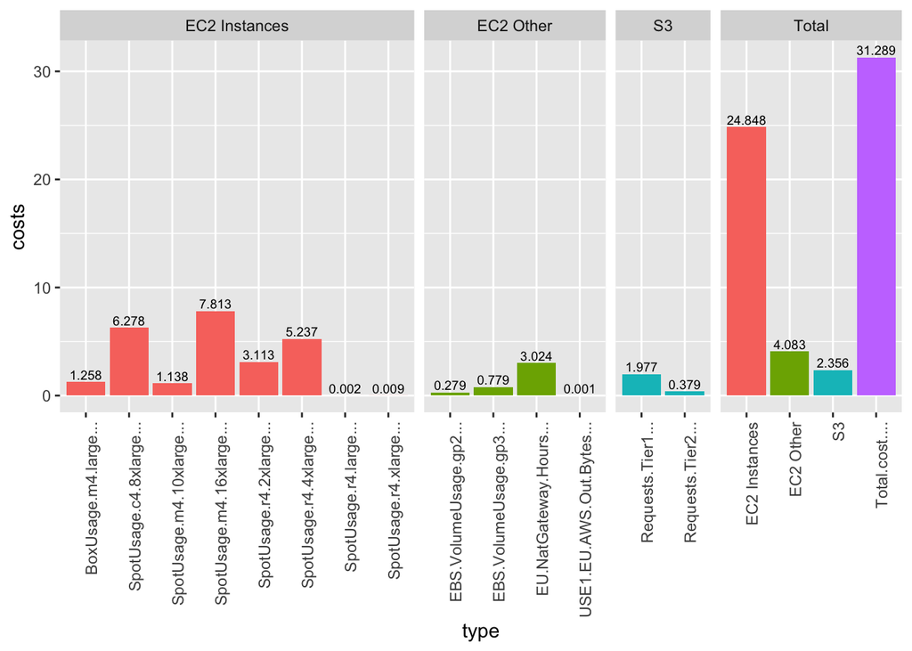

```r
ggplot(data=germline_singlesample_30_usage_aggr, aes(x=type, y=costs,fill=color)) +
  geom_bar(stat="identity") +
  theme(axis.text.x = element_text(angle=90, hjust = 1)) +
  theme(legend.position="none") +
  geom_text(aes(label = sprintf("%0.3f", round(costs, digits = 3))), vjust = -0.3, size=2.5) +
  facet_grid(~category, scales="free", space="free_x")
```

Todo:

1. How should we handle maintenance costs? subtract?
2. Naming a bit ugly….
3. How to combine plots for multiple aspects, -> possibly adding more rows in the above facet wrap?

# 5 Methods

Package versions:

```
## viridisLite      ggpubr  kableExtra       knitr     cowplot     ggplot2
##     "0.4.0"     "0.4.0"     "1.3.4"      "1.39"     "1.1.1"     "3.3.6"
##     forcats   patchwork       dplyr
##     "0.5.1"     "1.1.1"     "1.0.9"
```